# DAGs propuestas

## DAGs propuestas

```r
install.packages("bnlearn")
```

```r
library(bnlearn)
```

```r
set.seed(1234)
data=read.csv("~/SP-Transporte-en-Mexico/data_corregido.csv", stringsAsFactors = TRUE)
head(data)
```

| S | T | EST | D | O | L | V | ESC | A | H |
| --- | --- | --- | --- | --- | --- | --- | --- | --- | --- |
| 1 | 2 | 3 | 1 | 9 | 1 | 0 | 8 | 2 | 0 |
| 1 | 5 | 3 | 1 | 9 | 1 | 0 | 8 | 2 | 0 |
| 1 | 14 | 3 | 1 | 9 | 1 | 0 | 8 | 2 | 0 |
| 1 | 14 | 3 | 1 | 9 | 1 | 0 | 8 | 2 | 0 |
| 1 | 2 | 3 | 1 | 9 | 1 | 0 | 8 | 2 | 0 |
| 1 | 5 | 3 | 1 | 9 | 1 | 0 | 8 | 2 | 0 |

```r
data$S   = factor(data$S)     # sexo
data$A   = factor(data$A)     # edad_cat
data$EST = factor(data$EST)   # estrato
data$T   = factor(data$T)     # transporte
data$D   = factor(data$D)     # dia_viaje

data$O   = factor(data$O)     # entidad
data$L   = factor(data$L)     # localidad

data$H   = factor(data$H)     # tiempo_cat
data$V   = factor(data$V)     # autos_camionetas
data$ESC = factor(data$ESC)   # escolaridad
```

Para el manejo de la DAG se asignó una clave corta a cada variable: A = edad_cat, D = dia_viaje, EST = estrato, V = autos_camionetas, L = localidad, H = tiempo_cat,  
O = Entidad,  
ESC = escolaridad, S = sexo, T = transporte

La DAG 1 se formula con base en que la edad determina la educación y ésta se relaciona con el estrato sociodemográfico de la perosna y el tipo de transporte que utiliza, así como arcos en función de cuestiones geográficas y el tiempo de traslado, así como quizá el sexo interfiera con el medio de transporte.

```r
dag1 = empty.graph(nodes = c("A", "D", "EST", "V", "L", "H", "O", "ESC","S","T"))
```

```r
arc_set1 = matrix(c("A","ESC",
                   "ESC","EST",
                   "EST","V",
                   "V","T",
                   "T","H",
                   "S","T",
                   "D","T",
                   "O","L",
                   "L","EST",
                   "L","H"),
                 byrow = TRUE, ncol = 2,
                 dimnames = list(NULL, c("from","to")))
```

```r
arcs(dag1) = arc_set1
```

```r
dag1
```

```
  Random/Generated Bayesian network

  model:
   [A][D][O][S][L|O][ESC|A][EST|L:ESC][V|EST][T|D:V:S][H|L:T]
  nodes:                                 10
  arcs:                                  10
    undirected arcs:                     0
    directed arcs:                       10
  average markov blanket size:           3.00
  average neighbourhood size:            2.00
  average branching factor:              1.00

  generation algorithm:                  Empty
```

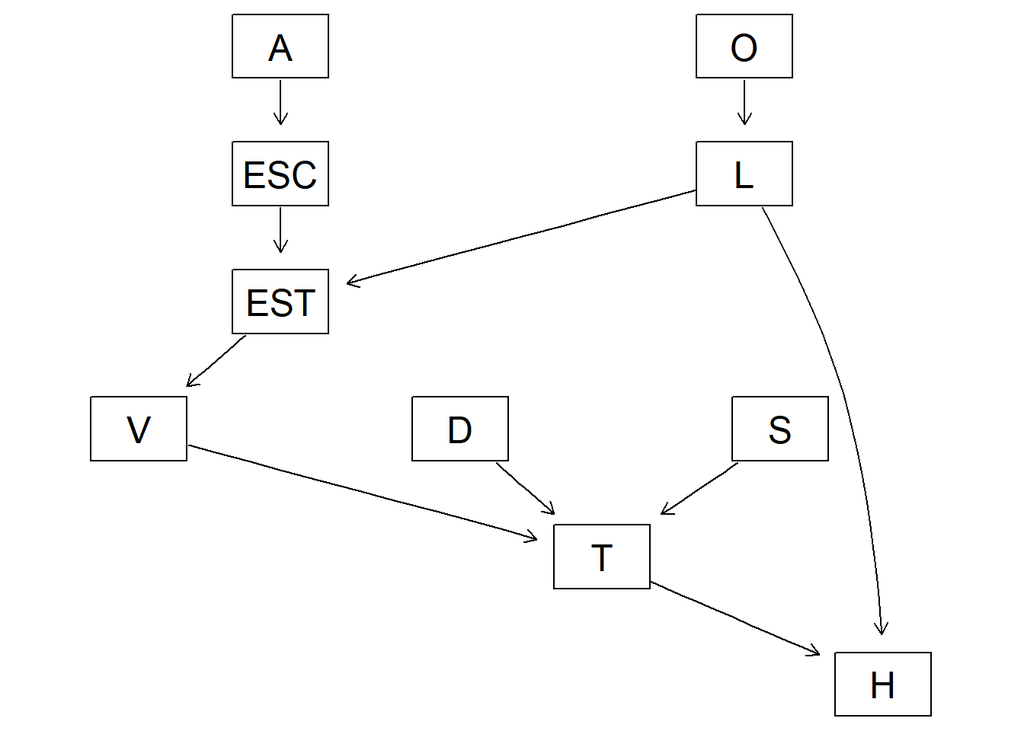

```r
graphviz.plot(dag1, shape = "rectangle")
```

```r
bn_mle=bn.fit(dag1,data=data, method='mle')
arc.strength(dag1, data = data, criterion = "mi")
```

| from | to | strength |
| --- | --- | --- |
| A | ESC | 0 |
| ESC | EST | 0 |
| EST | V | 0 |
| V | T | 0 |
| T | H | 0 |
| S | T | 0 |
| D | T | 0 |
| O | L | 0 |
| L | EST | 0 |
| L | H | 0 |

```r
arc.strength(dag1, data = data, criterion = "mi")
```

| from | to | strength |
| --- | --- | --- |
| A | ESC | 0 |
| ESC | EST | 0 |
| EST | V | 0 |
| V | T | 0 |
| T | H | 0 |
| S | T | 0 |
| D | T | 0 |
| O | L | 0 |
| L | EST | 0 |
| L | H | 0 |

```r
score(dag1, data = data, type = "bic")
```

```
[1] -7863114
```

```r
score(dag1, data = data, type = "aic")
```

```
[1] -7857363
```

La segunda DAG propuesta se centra principalmente en el entorno geográfico, es decir, que del lugar de origen o la localidad se relacionan el estrato, el tiempo del viaje, la cantidad de vehículos, así como otras relaciones entre el sexo y la edad para determinar la escolaridad y el medio de transporte.

```r
dag2 = empty.graph(nodes = c("A", "D", "EST", "V", "L", "H", "O", "ESC","S","T"))
```

```r
arc_set2 = matrix(c("O","L",
                   "L","EST",
                   "EST","T",
                   "O","H",
                   "L","H",
                   "EST","V",
                   "V","T",
                   "S","T",
                   "A","ESC",
                   "ESC","T",
                   "D","H"),
                 byrow = TRUE, ncol = 2,
                 dimnames = list(NULL, c("from","to")))
```

```r
arcs(dag2) = arc_set2
```

```r
dag2
```

```
  Random/Generated Bayesian network

  model:
   [A][D][O][S][L|O][ESC|A][EST|L][H|D:L:O][V|EST][T|EST:V:ESC:S]
  nodes:                                 10
  arcs:                                  11
    undirected arcs:                     0
    directed arcs:                       11
  average markov blanket size:           3.60
  average neighbourhood size:            2.20
  average branching factor:              1.10

  generation algorithm:                  Empty
```

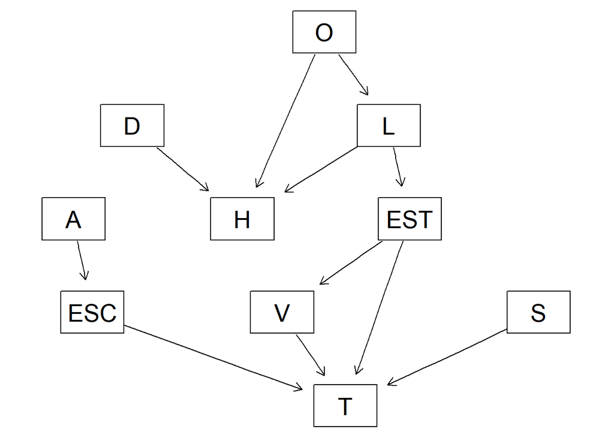

```r
graphviz.plot(dag2, shape = "rectangle")
```

```r
arc.strength(dag2, data = data, criterion = "mi")
```

| from | to | strength |
| --- | --- | --- |
| O | L | 0 |
| L | EST | 0 |
| EST | T | 0 |
| O | H | 0 |
| L | H | 0 |
| EST | V | 0 |
| V | T | 0 |
| S | T | 0 |
| A | ESC | 0 |
| ESC | T | 0 |
| D | H | 0 |

```r
score(dag2, data = data, type = "bic")
```

```
[1] -8032815
```

```r
score(dag2, data = data, type = "aic")
```

```
[1] -7944145
```

Por último, la tercera DAG se basa principalmente en factores personales como los determinantes de mayor impacto. Teniendo como nodos padres e independientes la edad y el sexo, y que a partir de éstos se condicionen otros aspectos relacionados con la movilidad de las personas, su escolaridad y el estrato en el que se encuentran.

```r
dag3 = empty.graph(nodes = c("A", "D", "EST", "V", "L", "H", "O", "ESC","S","T"))
```

```r
arc_set3 = matrix(c("A","ESC",
                   "ESC","EST",
                   "EST","T",
                   "T","H",
                   "S","T",
                   "A","V",
                   "V","T",
                   "O","L",
                   "L","T",
                   "D","T",
                   "L","H"),
                 byrow = TRUE, ncol = 2,
                 dimnames = list(NULL, c("from","to")))
```

```r
arcs(dag3) = arc_set3
```

```r
dag3
```

```
  Random/Generated Bayesian network

  model:
   [A][D][O][S][V|A][L|O][ESC|A][EST|ESC][T|D:EST:V:L:S][H|L:T]
  nodes:                                 10
  arcs:                                  11
    undirected arcs:                     0
    directed arcs:                       11
  average markov blanket size:           4.20
  average neighbourhood size:            2.20
  average branching factor:              1.10

  generation algorithm:                  Empty
```

```r
arc.strength(dag3, data = data, criterion = "mi")
```

| from | to | strength |
| --- | --- | --- |
| A | ESC | 0 |
| ESC | EST | 0 |
| EST | T | 0 |
| T | H | 0 |
| S | T | 0 |
| A | V | 0 |
| V | T | 0 |
| O | L | 0 |
| L | T | 0 |
| D | T | 0 |
| L | H | 0 |

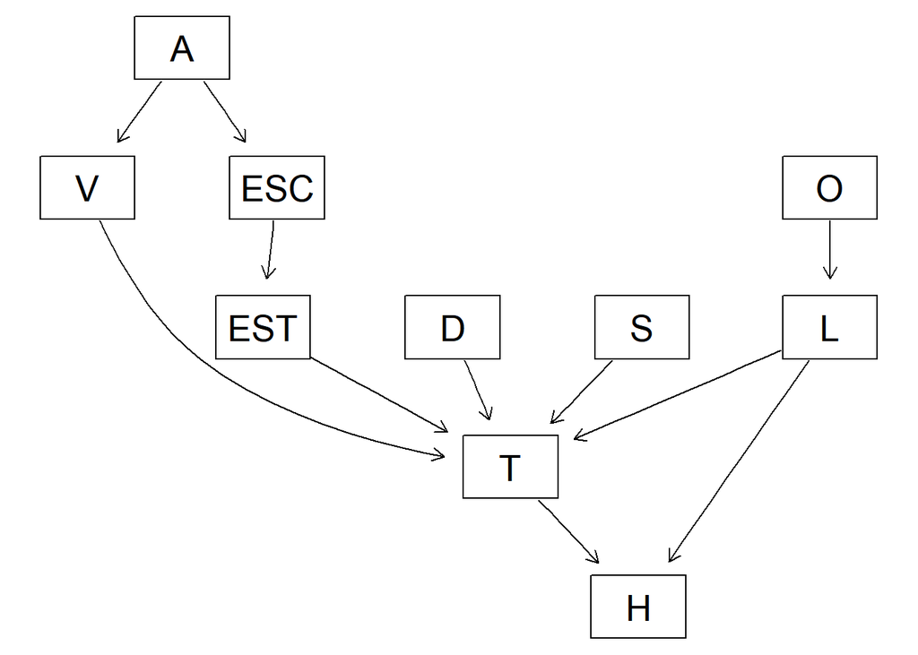

```r
graphviz.plot(dag3, shape = "rectangle")
```

```r
score(dag3, data = data, type = "bic")
```

```
[1] -7983492
```

```r
score(dag3, data = data, type = "aic")
```

```
[1] -7918357
```

```r
dim(data)
```

```
[1] 880835     10
```

Con base en los puntajes de la prueba BIC, aquella que tenía el mayor de éstas y en función de la librería bnlearn, se selecciona como mejor la primera DAG de las 3 propuestas.